# Codes

پروژه چهارم درس هوش مصنوعی  
Machine Learning

معین کرمی  
810198540

**هدف پروژه:**

**هدف از این پروژه آشنایی با Machine Learning و ساخت یک classifier است.**

**خلاصه ی مسئله:**

در این مسئله یک مجموعه داده شامل اطلاعات تعدادی قطعه‌ی موسیقی که شامل مدت زمان، انرژی، هنرمند و ... است به ما داده می‌شود و ما با ایجاد یک classifier با استفاده از متد Machine Learning و داده‌های در دسترس به مشخص کردن ژانر قطعه های مختلف موسیقی می‌پردازیم.

**فاز صفر: EDA and Visualization**

```python
import pandas as pd
import numpy as np
import matplotlib.pyplot as plt
import sklearn.feature_selection
import copy
from sklearn.metrics import f1_score
from sklearn.metrics import accuracy_score
from sklearn.metrics import recall_score
from sklearn.metrics import precision_score
from sklearn.ensemble import RandomForestClassifier
from sklearn.metrics import plot_confusion_matrix
```

```python
data = pd.read_csv('dataset.csv')

data.describe()
```

|  | popularity | acousticness | danceability | duration_ms | energy | instrumentalness | liveness | loudness | speechiness | tempo | valence |
| --- | --- | --- | --- | --- | --- | --- | --- | --- | --- | --- | --- |
| count | 30000.000000 | 30000.000000 | 30000.000000 | 2.699000e+04 | 30000.000000 | 30000.000000 | 30000.000000 | 30000.000000 | 30000.000000 | 27067.000000 | 30000.000000 |
| mean | 47.769533 | 0.359661 | 0.540929 | 2.466460e+05 | 0.556709 | 0.180807 | 0.183610 | -10.079862 | 0.083861 | 117.559824 | 0.446563 |
| std | 14.512665 | 0.364182 | 0.181719 | 1.126005e+05 | 0.277856 | 0.329365 | 0.150733 | 6.953936 | 0.093366 | 30.719934 | 0.248745 |
| min | 0.000000 | 0.000001 | 0.059600 | 1.550900e+04 | 0.000792 | 0.000000 | 0.015700 | -47.046000 | 0.022300 | 34.347000 | 0.000000 |
| 25% | 39.000000 | 0.029600 | 0.423000 | 1.904930e+05 | 0.361000 | 0.000000 | 0.095800 | -12.057250 | 0.035000 | 92.340000 | 0.243000 |
| 50% | 49.000000 | 0.205000 | 0.553000 | 2.245600e+05 | 0.602000 | 0.000089 | 0.122000 | -7.623000 | 0.045100 | 115.491000 | 0.435000 |
| 75% | 57.000000 | 0.710000 | 0.671000 | 2.726670e+05 | 0.786000 | 0.125250 | 0.222000 | -5.429750 | 0.080300 | 139.817500 | 0.639000 |
| max | 99.000000 | 0.996000 | 0.977000 | 3.195440e+06 | 0.998000 | 0.994000 | 0.996000 | 1.342000 | 0.941000 | 219.331000 | 0.985000 |

**1)**

تابع describe اطلاعات آماری هر ستون مانند چارک ها، کمینه، بیشینه و ... را به ما می‌دهد.

```python
data.info()
```

```
<class 'pandas.core.frame.DataFrame'>
RangeIndex: 30000 entries, 0 to 29999
Data columns (total 16 columns):
 #   Column            Non-Null Count  Dtype
---  ------            --------------  -----
 0   artist_name       28506 non-null  object
 1   track_name        30000 non-null  object
 2   popularity        30000 non-null  float64
 3   acousticness      30000 non-null  float64
 4   danceability      30000 non-null  float64
 5   duration_ms       26990 non-null  float64
 6   energy            30000 non-null  float64
 7   instrumentalness  30000 non-null  float64
 8   key               30000 non-null  object
 9   liveness          30000 non-null  float64
 10  loudness          30000 non-null  float64
 11  mode              30000 non-null  object
 12  speechiness       30000 non-null  float64
 13  tempo             27067 non-null  float64
 14  valence           30000 non-null  float64
 15  music_genre       30000 non-null  object
dtypes: float64(11), object(5)
memory usage: 3.7+ MB
```

تابع info اطلاعات کلی هر ستون مانند تایپ و تعداد مقادیر موجود را به ما می‌دهد.

**2)**

```python
data.apply(lambda col: col.isna().sum() / len(col) * 100)
```

```
artist_name          4.980000
track_name           0.000000
popularity           0.000000
acousticness         0.000000
danceability         0.000000
duration_ms         10.033333
energy               0.000000
instrumentalness     0.000000
key                  0.000000
liveness             0.000000
loudness             0.000000
mode                 0.000000
speechiness          0.000000
tempo                9.776667
valence              0.000000
music_genre          0.000000
dtype: float64
```

**3)**

```python
data.head()
```

|  | artist_name | track_name | popularity | acousticness | danceability | duration_ms | energy | instrumentalness | key | liveness | loudness | mode | speechiness | tempo | valence | music_genre |
| --- | --- | --- | --- | --- | --- | --- | --- | --- | --- | --- | --- | --- | --- | --- | --- | --- |
| 0 | Blockhead | Cheer up, You're Not Dead Yet | 44.0 | 0.00621 | 0.711 | 285987.0 | 0.6210 | 0.029700 | G | 0.159 | -7.429 | Major | 0.0382 | 142.065 | 0.607 | Jazz |
| 1 | FloFilz | Corners | 34.0 | 0.34700 | 0.729 | 103703.0 | 0.5150 | 0.006920 | C | 0.127 | -10.147 | Major | 0.1840 | 79.969 | 0.287 | Jazz |
| 2 | Bonobo | We Could Forever | 51.0 | 0.01810 | 0.669 | NaN | 0.8850 | 0.880000 | G | 0.265 | -7.080 | Minor | 0.0378 | NaN | 0.636 | Jazz |
| 3 | Nils Landgren | A Child Is Born | 39.0 | 0.91800 | 0.484 | 228733.0 | 0.0693 | 0.000069 | F | 0.139 | -15.542 | Major | 0.0346 | 82.707 | 0.206 | Jazz |
| 4 | Masayoshi Takanaka | Samba Pati | 36.0 | 0.03450 | 0.473 | 342867.0 | 0.8230 | 0.446000 | G | 0.306 | -6.625 | Major | 0.0630 | 104.694 | 0.383 | Jazz |

```python
# data['artist_name'].value_counts().plot(kind = 'bar')
```

```python
# data['track_name'].value_counts().plot(kind = 'bar')
```

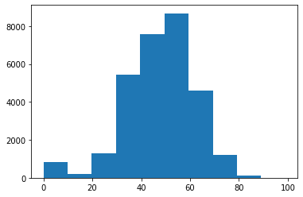

```python
plt.hist(data['popularity'])
```

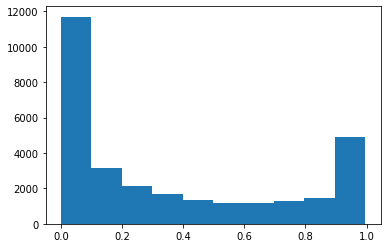

```python
plt.hist(data['acousticness'])
```

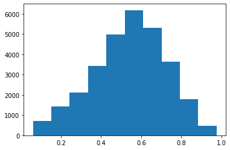

```python
plt.hist(data['danceability'])
```

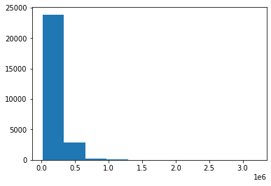

```python
plt.hist(data['duration_ms'])
```

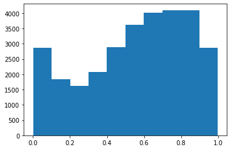

```python
plt.hist(data['energy'])
```

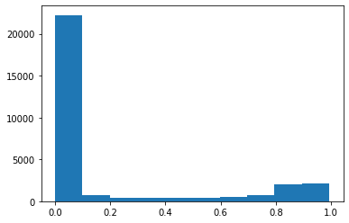

```python
plt.hist(data['instrumentalness'])
```

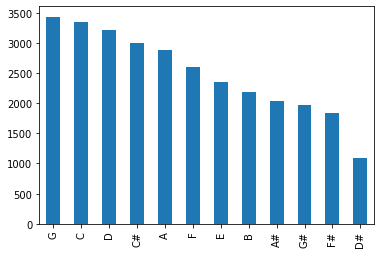

```python
data['key'].value_counts().plot(kind = 'bar')
```

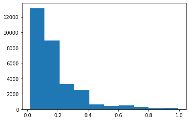

```python
plt.hist(data['liveness'])
```

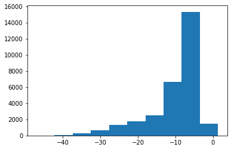

```python
plt.hist(data['loudness'])
```

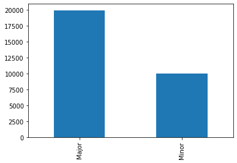

```python
data['mode'].value_counts().plot(kind = 'bar')
```

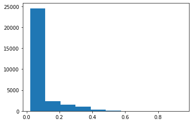

```python
plt.hist(data['speechiness'])
```

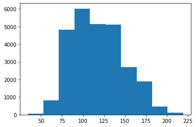

```python
plt.hist(data['tempo'])
```

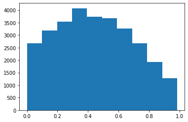

```python
plt.hist(data['valence'])
```

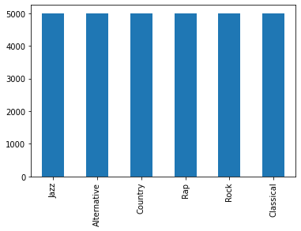

```python
data['music_genre'].value_counts().plot(kind = 'bar')
```

**فاز اول: Preprocessing**

**1)**

۱. حذف دیتا هایی که شامل مقدار NAN هستند.  
مزیت: این روش بسیار سریع و آسان است  
ایراد: ممکن است دیتاهایی که حذف می‌شوند شامل اطلاعات مهمی باشند و همچنین ممکن است داده های زیادی حذف شوند.  
2. پر کردن خانه های NAN با میانگین، میانه، مود و دیگر داده های آماری  
مزیت: در این متد هیچ دیتایی از دست نمی‌رود  
ایراد: اگر یک ستون مقدار زیادی NAN داشته باشد، دیتای بی معنی زیادی به وجود می‌آید.

**۲)**

به جای داده های NAN از مود(دیتا با بیشترین تکرار استفاده می‌کنیم)

```python
data.apply(lambda col: col.fillna(col.mode()[0], inplace = True))
```

```
artist_name         None
track_name          None
popularity          None
acousticness        None
danceability        None
duration_ms         None
energy              None
instrumentalness    None
key                 None
liveness            None
loudness            None
mode                None
speechiness         None
tempo               None
valence             None
music_genre         None
dtype: object
```

**3)**

Normalize: این متد متغیر های عددی را به یک عدد بین ۰ و ۱ تبدیل می‌کند که معادله این تبدیل برابر است با: $$ x_{new} = \frac{x_{old} - x_{min}}{x_{max} - x_{min}}$$
Standardization: در این متد متغیر ها به شکلی تغییر می‌کنند که میانگین آن ها برار ۰ و انحراف معیارشان برابر ۱ باشد. $$x_{new} = \frac{x_{old} - \mu}{\sigma}$$

**4)**

```python
data = data.apply(lambda col : col if isinstance(col[0], str) else (col - col.mean()) / col.std())
data
```

|  | artist_name | track_name | popularity | acousticness | danceability | duration_ms | energy | instrumentalness | key | liveness | loudness | mode | speechiness | tempo | valence | music_genre |
| --- | --- | --- | --- | --- | --- | --- | --- | --- | --- | --- | --- | --- | --- | --- | --- | --- |
| 0 | Blockhead | Cheer up, You're Not Dead Yet | -0.259741 | -0.970532 | 0.935904 | 0.423583 | 0.231381 | -0.458783 | G | -0.163272 | 0.381203 | Major | -0.489052 | 0.831331 | 0.644987 | Jazz |
| 1 | FloFilz | Corners | -0.948794 | -0.034765 | 1.034959 | -1.253933 | -0.150111 | -0.527946 | C | -0.375567 | -0.009655 | Major | 1.072549 | -1.296071 | -0.641471 | Jazz |
| 2 | Bonobo | We Could Forever | 0.222596 | -0.937884 | 0.704778 | -0.551790 | 1.181513 | 2.122853 | G | 0.539958 | 0.431391 | Minor | -0.493336 | 0.075798 | 0.761572 | Jazz |
| 3 | Nils Landgren | A Child Is Born | -0.604268 | 1.533131 | -0.313279 | -0.103312 | -1.754179 | -0.548746 | F | -0.295956 | -0.785474 | Major | -0.527610 | -1.202267 | -0.967105 | Jazz |
| 4 | Masayoshi Takanaka | Samba Pati | -0.810984 | -0.892852 | -0.373812 | 0.947036 | 0.958376 | 0.805165 | G | 0.811962 | 0.496821 | Major | -0.223430 | -0.448995 | -0.255534 | Jazz |
| ... | ... | ... | ... | ... | ... | ... | ... | ... | ... | ... | ... | ... | ... | ... | ... | ... |
| 29995 | Wolfgang Amadeus Mozart | Die Zauberflöte, K. 620: Wie stark ist nicht d... | -1.775658 | 1.513910 | -1.182754 | 1.184218 | -1.524924 | -0.548956 | G | -0.355665 | -1.497445 | Major | -0.301617 | -0.880807 | -0.967105 | Classical |
| 29996 | New York Philharmonic | Symphony No. 2 in D Major, Op. 73: II. Adagio ... | -1.500037 | 1.662188 | -2.283356 | 2.523892 | -1.269396 | 2.089455 | B | -0.514887 | -0.919499 | Major | -0.475128 | -1.211517 | -1.639681 | Classical |
| 29997 | Georges Bizet | Bizet: Carmen, WD 31, Act 1 Scene 4: No. 5, Ha... | 0.429312 | 1.692392 | -0.979143 | 0.204189 | -1.589705 | -0.548956 | D | -0.559999 | -1.041876 | Major | -0.160237 | 0.075798 | -0.866601 | Classical |
| 29998 | Edvard Grieg | Peer Gynt-Suite Nr. 1, Op. 46: I. Morning | -0.397552 | 1.717105 | -2.299865 | 0.180501 | -1.940966 | 2.201793 | E | -0.388836 | -1.954453 | Major | -0.461204 | -1.579194 | -1.653752 | Classical |
| 29999 | Johann Sebastian Bach | Suite No. 2 in B Minor, BWV 1067: VI. Menuet | -0.810984 | 1.132233 | -0.302273 | -1.521761 | -1.438548 | 2.201793 | G# | -0.242883 | -1.293963 | Minor | -0.496549 | 0.237676 | 0.693229 | Classical |

30000 rows × 16 columns

**5)**

۱. Label Encoding or Ordinal Encoding: در این روش به هر دسته یک عدد نسبت داده می‌شود، این متد بیشتر در داده هایی استفاده میشود که دسته ها در آن ترتیب دارند.  
۲. One Hot Encoding: فرض کنید یک ستون شامل داده دسته ای است که می‌تواند شامل x مقدار مختلف باشد.  
در این روش این ستون داده را حذف کرده و x ستون اضافه می‌کنیم و اگر در ستون اصلی این متغیر شامل دسته ی iام بود در خانه ی مربوط به این داده و ستون iام که جدید اضافه شده، ۱ می‌گذاریم و باقی خانه های مربوط به این دیتا در ستون های اضافه شده ۰ قرار می‌دهیم.  
من از متد اول استفاده می‌کنم چون متد دوم در داده های دسته ای که می‌توانند مقادیر مختلف زیادی داشته باشند(مانند ستون اول و دوم دیتای ما) بسیار بد عمل می‌کند و همچنین متد اول هم سربع تر است و هم فضای کمتری اشغال می‌کند

```python
tmp = data['music_genre']
data = data.apply(lambda col : col.astype('category').cat.codes if isinstance(col[0], str) else col)
data['music_genre'] = tmp
data['music_genre'] = data['music_genre'].astype('category')
```

**6)**

چون این ستون داده مقادیر مختلف بسیار زیادی دارد، نمی‌توان از One Hot Encoding استفاده کرد، ولی می‌توان از Label Encoding استفاده کرد

**7)**

```
<BarContainer object of 15 artists>
```

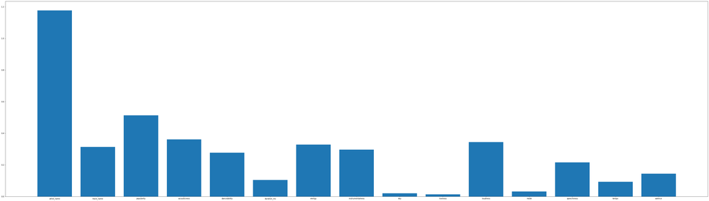

```python
fig = plt.figure(figsize = (70, 20))
cp = copy.deepcopy(data)
cp = cp.iloc[: , :-1]
info = sklearn.feature_selection.mutual_info_classif(cp, data['music_genre'])
plt.bar(cp.columns, info)
```

**8)**

اولین ویژگی یعنی نام خواننده با توجه به information gain بالایی که دارد در پیش‌بینی ژانر موسیقی مفید تر از بقیه است ولی متغیر هایی مثل mode, liveness, key, ... از میان متغیر های دیگر information gain خیلی کمی دارند و می‌تواند حذفشان کرد.  
مزیت حذف کردن: این کار هم مدل را ساده تر و هم سریع تر می‌کند و همچنین ممکن است حذف نکردن این ویژگی ها خطای ما را افزایش دهند و باعث overfitting شوند.  
معایب حذف کردن: این ویژگی ها ممکن است به تنهایی سود نداشته باشند و حتی باعث overfitting شوند ولی ممکن است ترکیب این ویژگی ها اطلاعات مفیدی برای ما داشته باشد و با حذف همه ی این ویژگی ها ما این اطلاعات را از دست بدهیم.  
ما 10 داده را حذف می‌کنیم .

```python
real_data = copy.deepcopy(data)
```

**فاز اول: Model Training, Evaluation and Hyper Parameter Tuning**

**1)**

مقدار p را برابر 10 در نظر می‌گیریم.  
بلی داده ها باید به صورت اتفاقی تقسیم شوند، چون در غیر این صورت مثلا اگر ۱۰ درصد داده اول را برای داده تست انتخاب کنیم، در این صورت تمام تست دیتای ما موسیقی جاز هستند و ما نمیتوانیم به درستی مدل خود را ارزیابی کنیم زیرا هیچ داده ی دیگری از ژانر های دیگر برای تست کردن نداریم.  
بهتر است که نسبت ژانر ها به کل در هر دو داده ی تست و هم ترین برابر باشد.  
برابر بودن این نسبت در داده ترین باعث می‌شود که مدل آموزش دیده ی ما بایاس نداشته باشد، به عبارت دیگر اگر از یک ژانر تعداد زیادی داده در ترین دیتا داشته باشیم و از ژانر دیگه ای مقدار کمی دیتا داشته باشیم، پیشبینی های ما بایاس دار می‌شوند و بیشتر به سمت ژانری می‌روند که سمپل های زیادی از آن دیده ایم و کمتر ژانری را پیش‌بینی می‌کند که دیتای کمی از آن دیده.  
برابر بودن این نسبت در تست دیتا باعث می‌شود که ما به درستی بتوانیم مدل خود را ارزیابی کنیم، چون کم بودن دیتا از یک ژانر خاص باعث می‌شود ما نتوانیم به درستی قدرت مدل خود را در پیشبینی این ژانر را ارزیابی کنیم.  
متغیر stratify در تابع train_test_split یک آرایه است که به صورت پیشفرض None است و اگر None نباشد، دیتا بر اساس این آرایه تقسیم می‌شود.

**2)**

```python
data = copy.deepcopy(real_data)
del data['mode']
del data['liveness']
del data['key']
del data['valence']
del data['tempo']
del data['duration_ms']
del data['speechiness']
del data['danceability']
del data['instrumentalness']
del data['track_name']

train, test = sklearn.model_selection.train_test_split(data, test_size = 0.1)
x_train = train.iloc[: , :-1]
x_test = test.iloc[: , :-1]
y_train = train.iloc[ : , len(train.columns) - 1]
y_test = test.iloc[ : , len(train.columns) - 1]
```

**3) KNN**

```python
def get_accuracy(pred, real):
    return sum(pred == real) / len(pred)
```

```python
from sklearn.neighbors import KNeighborsClassifier
train_acc = []
test_acc = []
best = 0
best_i = 1
for i in range(1, 50):
    knn = KNeighborsClassifier(n_neighbors = i)
    knn.fit(x_train, y_train)
    train_acc.append(accuracy_score(y_train, knn.predict(x_train)))
    tmp = accuracy_score(y_test, knn.predict(x_test))
    test_acc.append(tmp)
    if (best < tmp):
        best_i, best = i, tmp
```

```
1
```

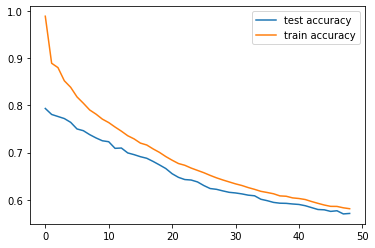

```python
print(best_i)
plt.plot(test_acc)
plt.plot(train_acc)
plt.legend(["test accuracy", "train accuracy"], loc ="upper right")
```

**4) Decision Tree**

```python
data = copy.deepcopy(real_data)
del data['mode']
del data['liveness']
del data['key']
del data['valence']
del data['tempo']
del data['duration_ms']
# del data['speechiness']
# del data['danceability']
# del data['instrumentalness']
# del data['track_name']
# del data['energy']
# del data['loudness']
# del data['acousticness']
train, test = sklearn.model_selection.train_test_split(data, test_size = 0.1)
x_train = train.iloc[: , :-1]
x_test = test.iloc[: , :-1]
y_train = train.iloc[ : , len(train.columns) - 1]
y_test = test.iloc[ : , len(train.columns) - 1]
```

```python
from sklearn import tree
train_acc = []
test_acc = []
best = 0
for i in range(1, 50):
    clf = tree.DecisionTreeClassifier(max_depth = i)
    clf = clf.fit(x_train, y_train)
    train_acc.append(accuracy_score(y_train, clf.predict(x_train)))
    tmp = accuracy_score(y_test, clf.predict(x_test))
    test_acc.append(tmp)
    if (best < tmp):
        best_i, best = i, tmp
```

```
8
```

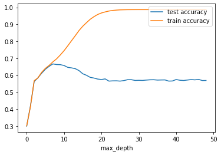

```python
print(best_i)
plt.plot(test_acc)
plt.plot(train_acc)
plt.xlabel('max_depth')
plt.legend(["test accuracy", "train accuracy"], loc ="upper right")
```

```python
train_acc = []
test_acc = []
best = 0
for i in range(1, 400):
    clf = tree.DecisionTreeClassifier(min_samples_leaf = i)
    clf = clf.fit(x_train, y_train)
    train_acc.append(accuracy_score(y_train, clf.predict(x_train)))
    tmp = accuracy_score(y_test, clf.predict(x_test))
    test_acc.append(tmp)
    if (best < tmp):
        best_i, best = i, tmp
```

```
66
```

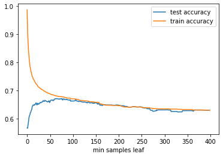

```python
print(best_i)
plt.plot(test_acc)
plt.plot(train_acc)
plt.xlabel('min samples leaf')
plt.legend(["test accuracy", "train accuracy"], loc ="upper right")
```

**5)**

**6)**

Recall : $$ Recall = \frac{Correct\ Detected\ Genre}{Total\ Genre}$$ این معیار محاسبه می‌کند که چند درصد از داده هایی که یک ژانر خاص را داشته اند، به درستی این ژانر را برای آن دیتا پیش‌بینی کرده ایم، ولی اهمیتی نمی‌دهد که چند دیتای اشتباه دیگر را در این ژانر طبقه بندی کرده ایم.
به بیان دیگر False Positive در این معیار تاثیری ندارد.
Precision: $$Preciion = \frac{Correct\ Detected\ Genre}{All Detected Genre}$$ این معیار محاسبه می‌کند چند درصد از داده هایی که برای آن ها یک ژانر خاص پیش‌بینی شده است، به درستی پیش بینی شده اند. ولی اهمیتی نمی‌دهد چند دیتا از این ژانر بوده‌اند ولی ژانر آن ها چیز دیگری تشخیص داده شده است.
به عبارت دیگر False Negative در این معیار تاثیری ندارد.
Accuracy: $$Accuracy = \frac{Correct\ Detected}{Total}$$ در این معیار به درصد تشخیص های درست اهمیت داده میشود و به طور شهودی برابر با میانگین دو معیار بالاست.
F1 Score: $$F1 = 2 \times \frac{Precision \times Recall}{Precision + Recall}$$ این معیار میانگین هارمونیک دو معیار اولیه است در نتیجه اگر یکی از این معیار ها خیلی پایین باشد، این معیار نیز به آن متمایل می‌شود و امتیاز کمی می‌گیریم.

```python
def calculate_accuracy(true_values, predicted_values):
    true_gues= 0;
    for i, j in zip(true_values, predicted_values):
        true_gues += int(i == j)
    return true_gues / len(true_values)

def calculate_precision(true_values, predicted_values, label):
    correct_gues = 0
    all_gues = 0
    for i, j in zip(true_values, predicted_values):
        if j == label:
            all_gues += 1
            if i == j:
                correct_gues += 1
    return correct_gues / all_gues

def calculate_recall(true_values, predicted_values, label):
    correct_gues = 0
    in_label = 0
    for i, j in zip(true_values, predicted_values):
        if i == label:
            in_label += 1
            if i == j:
                correct_gues += 1
    return correct_gues / in_label

def calculate_f1(true_values, predicted_values, label):
    recall = self.calculate_recall(true_values, predicted_values, label)
    precision = self.calculate_precision(true_values, predicted_values, label)
    if (recall + precision == 0):
        return 0
    return 2 * (recall * precision) / (recall + precision)
```

**KNN Accuracy)**

```python
data = copy.deepcopy(real_data)
del data['mode']
del data['liveness']
del data['key']
del data['valence']
del data['tempo']
del data['duration_ms']
del data['speechiness']
del data['danceability']
del data['instrumentalness']
del data['track_name']
train, test = sklearn.model_selection.train_test_split(data, test_size = 0.1)
x_train = train.iloc[: , :-1]
x_test = test.iloc[: , :-1]
y_train = train.iloc[ : , len(train.columns) - 1]
y_test = test.iloc[ : , len(train.columns) - 1]
```

```python
knn = KNeighborsClassifier(n_neighbors = 1)
knn.fit(x_train, y_train)
train_pred = knn.predict(x_train)
test_pred = knn.predict(x_test)

print("Train Accuracy : " + str(accuracy_score(y_train, train_pred)))
print("Train F1 Score : " + str(f1_score(y_train, train_pred, average = 'weighted')))
print("Train Recall : " + str(recall_score(y_train, train_pred, average = 'weighted')))
print("Train Precision : " + str(precision_score(y_train, train_pred, average = 'weighted')))
print()
print("Test Accuracy : " + str(accuracy_score(y_test, test_pred)))
print("Test F1 Score : " + str(f1_score(y_test, test_pred, average = 'weighted')))
print("Test Recall : " + str(recall_score(y_test, test_pred, average = 'weighted')))
print("Test Precision : " + str(precision_score(y_test, test_pred, average = 'weighted')))
```

```
Train Accuracy : 0.988
Train F1 Score : 0.9879992326699449
Train Recall : 0.988
Train Precision : 0.9880005879238584

Test Accuracy : 0.788
Test F1 Score : 0.788683532364431
Test Recall : 0.788
Test Precision : 0.7896768649163889
```

**Decision Accuracy)**

```python
data = copy.deepcopy(real_data)
del data['mode']
del data['liveness']
del data['key']
del data['valence']
del data['tempo']
del data['duration_ms']
# del data['speechiness']
# del data['danceability']
# del data['instrumentalness']
# del data['track_name']
# del data['energy']
# del data['loudness']
# del data['acousticness']
train, test = sklearn.model_selection.train_test_split(data, test_size = 0.1)
x_train = train.iloc[: , :-1]
x_test = test.iloc[: , :-1]
y_train = train.iloc[ : , len(train.columns) - 1]
y_test = test.iloc[ : , len(train.columns) - 1]
```

```python
clf = tree.DecisionTreeClassifier(max_depth = 9, min_samples_leaf = 59)
clf = clf.fit(x_train, y_train)
train_pred = clf.predict(x_train)
test_pred = clf.predict(x_test)

print("Train Accuracy : " + str(accuracy_score(y_train, train_pred)))
print("Train F1 Score : " + str(f1_score(y_train, train_pred, average = 'weighted')))
print("Train Recall : " + str(recall_score(y_train, train_pred, average = 'weighted')))
print("Train Precision : " + str(precision_score(y_train, train_pred, average = 'weighted')))
print()
print("Test Accuracy : " + str(accuracy_score(y_test, test_pred)))
print("Test F1 Score : " + str(f1_score(y_test, test_pred, average = 'weighted')))
print("Test Recall : " + str(recall_score(y_test, test_pred, average = 'weighted')))
print("Test Precision : " + str(precision_score(y_test, test_pred, average = 'weighted')))
```

```
Train Accuracy : 0.6751111111111111
Train F1 Score : 0.6711649570552406
Train Recall : 0.6751111111111111
Train Precision : 0.6781257073131383

Test Accuracy : 0.6583333333333333
Test F1 Score : 0.6525222379157876
Test Recall : 0.6583333333333333
Test Precision : 0.6632296487993072
```

**7)**

**فاز سوم: Ensemble Methods**

**1)**

```python
data = copy.deepcopy(real_data)
del data['mode']
del data['liveness']
del data['key']
del data['valence']
del data['tempo']
# del data['duration_ms']
# del data['speechiness']
# del data['danceability']
# del data['instrumentalness']
# del data['track_name']
train, test = sklearn.model_selection.train_test_split(data, test_size = 0.1)
x_train = train.iloc[: , :-1]
x_test = test.iloc[: , :-1]
y_train = train.iloc[ : , len(train.columns) - 1]
y_test = test.iloc[ : , len(train.columns) - 1]
```

```python
clf = RandomForestClassifier(max_depth = 9, min_samples_leaf = 67);
clf.fit(x_train, y_train)
```

```
RandomForestClassifier(max_depth=9, min_samples_leaf=67)
```

**2)**

max_depth: .این متغیر حداکثر ارتفاع هر درخت در جنگل را مشخص می‌کند افزایش این متغیر باعث میشود مدل ما بیشتر با داده‌ی train فیت شود در نتیجه محدود کردن آن باعث کمتر شدن واریانس و افزایش بایاس می‌شود.  
leaf_samples_min: فرض کنید این متغیر برابر x باشد، در این حالت هر جا که اسپلیت کردن یک راس به کمتر از ۱۰ برگ برسد، اسپلیت کردن این راس متوقف می‌شود. تاثیر این متغیر نیز مانند متغیر بالاست، با این تفاوت که افزایش آن باعث کمتر فیت شدن درخت با داده ی ترین می‌شود و باعث واریانس کمتر و بایاس بیشتر می‌شود.  
n_estimators: این متغیر برابر درخت های داخل جنگل است. افزایش این متغیر باعث افزایش محاسبات و کندی برنامه می‌شود  
افزایش این متغیر همیشه نتیجه را بهبود نمی‌بخشد چرا که افزایش بیش از حد آن ممکن است باعث شود درخت ها به هم وابستگی پیدا کنند که این اتفاق باعث کاهش دقت می‌شود.

**3)**

```python
data = copy.deepcopy(real_data)
del data['mode']
del data['liveness']
del data['key']
# del data['valence']
# del data['tempo']
# del data['duration_ms']
# del data['speechiness']
# del data['danceability']
# del data['instrumentalness']
# del data['track_name']
train, test = sklearn.model_selection.train_test_split(data, test_size = 0.1)
x_train = train.iloc[: , :-1]
x_test = test.iloc[: , :-1]
y_train = train.iloc[ : , len(train.columns) - 1]
y_test = test.iloc[ : , len(train.columns) - 1]


clf = RandomForestClassifier(n_estimators = 300, max_depth = 15, min_samples_leaf = 10);
clf.fit(x_train, y_train)
train_pred = clf.predict(x_train)
test_pred = clf.predict(x_test)

print("Train Accuracy : " + str(accuracy_score(y_train, train_pred)))
print("Train F1 Score : " + str(f1_score(y_train, train_pred, average = 'weighted')))
print("Train Recall : " + str(recall_score(y_train, train_pred, average = 'weighted')))
print("Train Precision : " + str(precision_score(y_train, train_pred, average = 'weighted')))
print()
print("Test Accuracy : " + str(accuracy_score(y_test, test_pred)))
print("Test F1 Score : " + str(f1_score(y_test, test_pred, average = 'weighted')))
print("Test Recall : " + str(recall_score(y_test, test_pred, average = 'weighted')))
print("Test Precision : " + str(precision_score(y_test, test_pred, average = 'weighted')))
```

```
Train Accuracy : 0.7840370370370371
Train F1 Score : 0.7821170915098762
Train Recall : 0.7840370370370371
Train Precision : 0.7940165267177965

Test Accuracy : 0.7253333333333334
Test F1 Score : 0.7227112987322191
Test Recall : 0.7253333333333334
Test Precision : 0.7336866159977756
```

**4)**

```
<sklearn.metrics._plot.confusion_matrix.ConfusionMatrixDisplay at 0x7faf17e21d00>
```

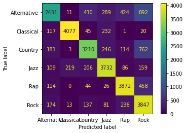

```python
plot_confusion_matrix(clf, x_train, y_train)
```